# GEE Complete Guide

Generalized Estimating Equations for Longitudinal Data

## 1. What is GEE?

Generalized Estimating Equations (GEE) provide a **population-averaged (marginal)** approach for analyzing correlated data, particularly longitudinal and clustered outcomes.

### Key Features

| Feature | Description |
| --- | --- |
| **Target** | Population-averaged (marginal) effects |
| **Distribution** | Does not require full distribution specification |
| **Robustness** | Robust to working correlation misspecification (with sandwich SE) |
| **Estimation** | Quasi-likelihood approach |
| **Standard Errors** | Uses sandwich (robust) estimator |

### Core Idea

GEE answers: *“How does the average response in the population change with covariates?”*

Unlike GLMMs, GEE does not model individual-specific trajectories. Instead, it directly estimates the marginal mean:

$$E(Y_{ij} | X_{ij}) = g^{-1}(X_{ij}^T \beta)$$

where $g$ is the link function (e.g., logit for binary outcomes).

**ImportantThe Sandwich Estimator is Key**

GEE’s robustness comes from the **sandwich (robust) standard errors**, which remain valid even if the working correlation structure is misspecified. Always use robust SEs in practice!

## 2. GEE vs GLMM Comparison

| Aspect | GEE | GLMM |
| --- | --- | --- |
| **Target** | Population average | Subject-specific |
| **Interpretation** | Marginal effects | Conditional on random effects |
| **Requires distribution** | No (quasi-likelihood) | Yes (full likelihood) |
| **Random effects** | No | Yes |
| **Robust to correlation misspecification** | Yes (with sandwich SE) | No |
| **Valid under MAR** | No (need IPW-GEE) | Yes |
| **Coefficient magnitude (binary)** | Smaller | Larger |
| **Model comparison** | QIC | AIC/BIC/LRT |

### When to Use Each

| Scenario | Recommended Approach |
| --- | --- |
| Interest in population-level inference | **GEE** |
| Interest in individual trajectories | **GLMM** |
| Few clusters (< 30) | **GLMM** (or GEE with small-sample correction) |
| Correlation structure uncertain | **GEE** (robust to misspecification) |
| Missing data (MAR mechanism) | **GLMM** or **IPW-GEE** |
| Simple, robust analysis | **GEE** |

### Coefficient Interpretation Example (Binary Outcome)

For a treatment effect with binary outcome (logit link):

- **GEE**: “The odds of the outcome in the treated group are $e^{\beta}$ times the odds in the control group, on average in the population.”
- **GLMM**: “For a given subject, the odds of the outcome when treated are $e^{\beta}$ times the odds when not treated, holding random effects constant.”

**NoteMarginal vs Conditional**

For non-linear models (e.g., logistic), marginal (GEE) coefficients are attenuated toward zero compared to conditional (GLMM) coefficients. This is not a bias—it reflects different targets of inference.

## 3. Working Correlation Structures

GEE uses a **working correlation** structure to improve efficiency. The key insight: even if misspecified, sandwich SEs remain valid.

| Structure | Assumption | When to Use | `geepack` syntax |
| --- | --- | --- | --- |
| **Independence** | $\text{Corr}(Y_{ij}, Y_{ik}) = 0$ | Baseline; conservative | `corstr = "independence"` |
| **Exchangeable** | $\text{Corr}(Y_{ij}, Y_{ik}) = \rho$ for all $j \neq k$ | Clustered data; similar within-cluster correlation | `corstr = "exchangeable"` |
| **AR(1)** | $\text{Corr}(Y_{ij}, Y_{ik}) = \rho^{\|j-k\|}$ | Equally-spaced longitudinal data; correlation decays | `corstr = "ar1"` |
| **Unstructured** | All correlations freely estimated | Small clusters; exploratory | `corstr = "unstructured"` |

### Correlation Structure Formulas

**Exchangeable (Compound Symmetry)**:
$$R_{jk} = \begin{cases} 1 & j = k \\ \rho & j \neq k \end{cases}$$

**AR(1)**:
$$R_{jk} = \rho^{|j-k|}$$

**Unstructured**:
$$R_{jk} = \rho_{jk} \text{ (each pair estimated separately)}$$

### Practical Guidance

1. **Start with exchangeable** for clustered data or longitudinal data with moderate follow-up
2. **Use AR(1)** for longitudinal data with time-ordered measurements
3. **Independence** gives valid (but inefficient) inference
4. **Unstructured** requires many parameters—use only with small cluster sizes

**TipRobustness Matters More Than Efficiency**

Choosing the “correct” working correlation improves efficiency but is not required for valid inference. With robust SEs, any working correlation gives valid hypothesis tests and confidence intervals.

## 4. The Sandwich Estimator

### Why Standard (Model-Based) SEs Fail

Model-based SEs assume the working correlation is correctly specified. If wrong, they can be severely biased (either direction).

### The Sandwich Formula

The robust variance estimator has the “sandwich” form:

$$\widehat{\text{Var}}(\hat{\beta}) = B^{-1} M B^{-1}$$

where:

- $B$ = model-based information matrix (“bread”)
- $M$ = empirical covariance of score contributions (“meat”)

### Key Properties

| Property | Explanation |
| --- | --- |
| **Consistent** | Converges to true variance as $n \to \infty$ |
| **Robust** | Valid even with misspecified working correlation |
| **Cluster-robust** | Accounts for within-cluster dependence |

### The Trade-off

**WarningSample Size Requirement**

The sandwich estimator requires **enough clusters** for reliable performance:

- Rule of thumb: $n \geq 30-50$ clusters
- With fewer clusters, sandwich SEs tend to be **biased downward** (anti-conservative)
- Use small-sample corrections when $n < 40$

## 5. Small Sample Corrections

### The Problem

With few clusters, the sandwich estimator underestimates variance, leading to:

- Inflated Type I error rates
- Confidence intervals that are too narrow

### Solutions

| Correction | Description | When to Use |
| --- | --- | --- |
| **Bias-corrected (BC)** | Adjusts for finite-sample bias | $n = 20-40$ clusters |
| **Jackknife** | Leave-one-cluster-out variance | $n = 15-40$ clusters |
| **Bootstrap** | Cluster bootstrap | Flexible; any $n$ |
| **Fay’s correction** | Modified BC | Very small $n$ |

### R Implementation with `geepack`

```r
# Standard fit
fit <- geeglm(y ~ x, id = id, data = dat,
              family = binomial, corstr = "exchangeable")

# Extract robust SEs (default)
summary(fit)$coefficients[, "Std.err"]

# For small-sample corrections, use additional packages:
# - geesmv: small-sample variance corrections
# - clubSandwich: cluster-robust SEs with corrections
```

### Using `clubSandwich` for Small Samples

```r
library(clubSandwich)

# Fit GEE
fit <- geeglm(y ~ x, id = id, data = dat,
              family = binomial, corstr = "exchangeable")

# CR2 correction (recommended for small samples)
coef_test(fit, vcov = "CR2", cluster = dat$id)
```

## 6. Complete R Example

### Setup: Epilepsy Data Pattern

```r
set.seed(667)

# Simulate epilepsy-like data
n_subjects <- 60
n_visits <- 4

# Create data structure
dat <- data.frame(
  id = rep(1:n_subjects, each = n_visits),
  visit = rep(0:(n_visits-1), n_subjects),
  trt = rep(rbinom(n_subjects, 1, 0.5), each = n_visits),
  age = rep(rnorm(n_subjects, 30, 10), each = n_visits)
)

# Generate subject-specific random effects
subject_re <- rnorm(n_subjects, 0, 0.8)

# Generate correlated binary outcomes (seizure-free: yes/no)
dat$eta <- -1 + 0.5 * dat$trt + 0.3 * dat$visit - 0.02 * dat$age +
           subject_re[dat$id]
dat$prob <- plogis(dat$eta)
dat$seizure_free <- rbinom(nrow(dat), 1, dat$prob)

# Convert id to factor
dat$id <- factor(dat$id)

head(dat)
```

```
  id visit trt       age        eta      prob seizure_free
1  1     0   0  9.879004 -1.6556133 0.1603517            0
2  1     1   0  9.879004 -1.3556133 0.2049542            0
3  1     2   0  9.879004 -1.0556133 0.2581486            0
4  1     3   0  9.879004 -0.7556133 0.3195994            0
5  2     0   0 42.429798 -1.9808038 0.1212332            0
6  2     1   0 42.429798 -1.6808038 0.1569891            1
```

### Fit GEE with Exchangeable Correlation

```r
# Fit GEE
fit_gee <- geeglm(seizure_free ~ trt + visit + age,
                  id = id,
                  data = dat,
                  family = binomial(link = "logit"),
                  corstr = "exchangeable")

summary(fit_gee)
```

```
Call:
geeglm(formula = seizure_free ~ trt + visit + age, family = binomial(link = "logit"),
    data = dat, id = id, corstr = "exchangeable")

 Coefficients:
            Estimate  Std.err  Wald Pr(>|W|)
(Intercept) -0.87326  0.45421 3.696   0.0545 .
trt          0.29781  0.29302 1.033   0.3095
visit        0.25407  0.11167 5.176   0.0229 *
age         -0.01251  0.01265 0.978   0.3226
---
Signif. codes:  0 '***' 0.001 '**' 0.01 '*' 0.05 '.' 0.1 ' ' 1

Correlation structure = exchangeable
Estimated Scale Parameters:

            Estimate Std.err
(Intercept)   0.9954 0.05937
  Link = identity

Estimated Correlation Parameters:
      Estimate Std.err
alpha  0.03303 0.05176
Number of clusters:   60  Maximum cluster size: 4
```

### Extract and Interpret Results

```r
# Extract coefficients
coefs <- summary(fit_gee)$coefficients
print(coefs)
```

```
            Estimate Std.err   Wald Pr(>|W|)
(Intercept) -0.87326 0.45421 3.6963  0.05453
trt          0.29781 0.29302 1.0330  0.30947
visit        0.25407 0.11167 5.1762  0.02290
age         -0.01251 0.01265 0.9784  0.32258
```

```r
# Odds ratios with 95% CI
or_results <- data.frame(
  Variable = rownames(coefs),
  OR = exp(coefs[, "Estimate"]),
  Lower = exp(coefs[, "Estimate"] - 1.96 * coefs[, "Std.err"]),
  Upper = exp(coefs[, "Estimate"] + 1.96 * coefs[, "Std.err"]),
  P_value = coefs[, "Pr(>|W|)"]
)
print(or_results, digits = 3)
```

```
     Variable    OR Lower Upper P_value
1 (Intercept) 0.418 0.171  1.02  0.0545
2         trt 1.347 0.758  2.39  0.3095
3       visit 1.289 1.036  1.60  0.0229
4         age 0.988 0.963  1.01  0.3226
```

### Working Correlation Estimate

```r
# Extract estimated correlation
fit_gee$geese$alpha
```

```
  alpha
0.03303
```

### Compare to GLMM

```r
# Fit GLMM for comparison
fit_glmm <- glmer(seizure_free ~ trt + visit + age + (1 | id),
                  data = dat, family = binomial)

# Compare coefficients
comparison <- data.frame(
  Variable = names(fixef(fit_glmm)),
  GEE = coef(fit_gee),
  GLMM = fixef(fit_glmm)
)
comparison$Ratio <- comparison$GLMM / comparison$GEE
print(comparison, digits = 3)
```

```
               Variable     GEE   GLMM Ratio
(Intercept) (Intercept) -0.8733 -0.899  1.03
trt                 trt  0.2978  0.307  1.03
visit             visit  0.2541  0.262  1.03
age                 age -0.0125 -0.013  1.04
```

**NoteCoefficient Comparison**

Notice that GLMM coefficients are larger in magnitude than GEE coefficients. This is expected for binary outcomes—marginal effects are attenuated compared to conditional effects.

### Compare Correlation Structures

```r
# Independence
fit_ind <- geeglm(seizure_free ~ trt + visit + age,
                  id = id, data = dat, family = binomial,
                  corstr = "independence")

# Exchangeable (already fit above)

# AR(1)
fit_ar1 <- geeglm(seizure_free ~ trt + visit + age,
                  id = id, data = dat, family = binomial,
                  corstr = "ar1")

# Unstructured
fit_un <- geeglm(seizure_free ~ trt + visit + age,
                 id = id, data = dat, family = binomial,
                 corstr = "unstructured")

# Compare QIC (not AIC!)
qic_compare <- data.frame(
  Structure = c("Independence", "Exchangeable", "AR(1)", "Unstructured"),
  QIC = c(QIC(fit_ind)[1], QIC(fit_gee)[1], QIC(fit_ar1)[1], QIC(fit_un)[1])
)
print(qic_compare)
```

```
     Structure   QIC
1 Independence 306.0
2 Exchangeable 306.0
3        AR(1) 306.0
4 Unstructured 305.6
```

## 7. GEE Diagnostics

### Residual Analysis

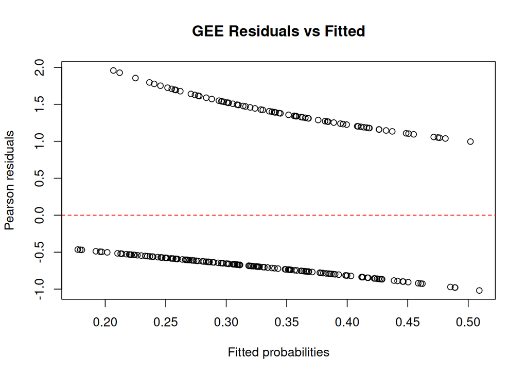

```r
# Pearson residuals
dat$pearson_resid <- residuals(fit_gee, type = "pearson")

# Plot residuals vs fitted
plot(fitted(fit_gee), dat$pearson_resid,
     xlab = "Fitted probabilities", ylab = "Pearson residuals",
     main = "GEE Residuals vs Fitted")
abline(h = 0, lty = 2, col = "red")
```

### Checking Working Correlation

```r
# Compare coefficient estimates across structures
coef_compare <- data.frame(
  Independence = coef(fit_ind),
  Exchangeable = coef(fit_gee),
  AR1 = coef(fit_ar1),
  Unstructured = coef(fit_un)
)
round(coef_compare, 3)
```

```
            Independence Exchangeable    AR1 Unstructured
(Intercept)       -0.872       -0.873 -0.875       -0.832
trt                0.298        0.298  0.300        0.280
visit              0.254        0.254  0.255        0.269
age               -0.013       -0.013 -0.013       -0.013
```

**TipStability Across Structures**

If coefficient estimates are similar across working correlation structures, this suggests robustness. Large differences may indicate model misspecification or influential observations.

### QIC for Model Selection

**Use QIC (Quasi-likelihood under Independence Criterion), NOT AIC!**

QIC is the appropriate analog of AIC for GEE:

$$\text{QIC} = -2Q(\hat{\beta}) + 2p$$

where $Q$ is the quasi-likelihood and $p$ is the number of parameters.

```r
# QIC comparison
cat("QIC values:\n")
```

```
QIC values:
```

```r
cat("Independence:", QIC(fit_ind)[1], "\n")
```

```
Independence: 306
```

```r
cat("Exchangeable:", QIC(fit_gee)[1], "\n")
```

```
Exchangeable: 306
```

```r
cat("AR(1):", QIC(fit_ar1)[1], "\n")
```

```
AR(1): 306
```

```r
cat("Unstructured:", QIC(fit_un)[1], "\n")
```

```
Unstructured: 305.6
```

## 8. IPW-GEE for MAR

### The Problem

Standard GEE is valid only under **MCAR** (Missing Completely at Random). Under **MAR** (Missing at Random), GEE estimates can be biased.

### Solution: Inverse Probability Weighting

IPW-GEE weights observations by the inverse probability of being observed:

$$w_{ij} = \frac{1}{P(\text{observed}_{ij} | \text{covariates})}$$

### Implementation Sketch

```r
# Step 1: Model missingness
miss_model <- glm(observed ~ lag_y + x + time,
                  data = dat, family = binomial)

# Step 2: Calculate weights
dat$prob_obs <- predict(miss_model, type = "response")
dat$ipw <- 1 / dat$prob_obs

# Step 3: Fit weighted GEE
fit_ipw <- geeglm(y ~ x + time, id = id, data = dat[dat$observed == 1, ],
                  family = binomial, corstr = "exchangeable",
                  weights = ipw)
```

**WarningIPW-GEE Considerations**

- Requires correct model for missingness mechanism
- Extreme weights can inflate variance
- Often combined with weight stabilization or trimming

## 9. Common Mistakes

### Mistake 1: Using Model-Based SEs

```r
# WRONG: naive/model-based SEs
# (geepack uses robust by default, but other packages may not)

# CORRECT: Always use robust (sandwich) SEs
summary(fit_gee)$coefficients[, "Std.err"]  # These ARE robust in geepack
```

### Mistake 2: Using AIC Instead of QIC

```r
# WRONG
AIC(fit_gee)  # Not appropriate for GEE

# CORRECT
QIC(fit_gee)  # Use QIC for quasi-likelihood models
```

### Mistake 3: Too Few Clusters

| Number of Clusters | Recommendation |
| --- | --- |
| $n < 20$ | Consider GLMM instead |
| $n = 20-40$ | Use small-sample corrections |
| $n > 40$ | Standard GEE likely okay |

### Mistake 4: Subject-Specific Interpretation

```r
# WRONG interpretation:
# "For an individual patient, treatment increases odds by..."

# CORRECT interpretation:
# "In the population, treatment is associated with X times higher odds of..."
```

### Mistake 5: Ignoring MAR

```r
# WRONG: Standard GEE with dropout
fit <- geeglm(y ~ trt + time, id = id, data = dat, ...)  # Biased under MAR

# CORRECT: Use IPW-GEE or GLMM
```

## 10. Quick Reference

### Essential Code

| Task | Code |
| --- | --- |
| Fit GEE | `geeglm(y ~ x, id = id, family = binomial, corstr = "exchangeable", data = dat)` |
| Get robust SEs | `summary(fit)$coefficients[, "Std.err"]` |
| Odds ratios | `exp(coef(fit))` |
| 95% CI | `exp(coef(fit) +/- 1.96 * SE)` |
| Working correlation | `fit$geese$alpha` |
| Model comparison | `QIC(fit1); QIC(fit2)` |

### Correlation Structure Quick Guide

| Data Pattern | Recommended Structure |
| --- | --- |
| Clustered (e.g., patients in clinics) | `exchangeable` |
| Longitudinal, equal spacing | `ar1` |
| Longitudinal, irregular spacing | `exchangeable` or `independence` |
| Few time points per subject | `unstructured` |
| Uncertain | `independence` (conservative) |

### Decision Flowchart

```
Population-level inference? --> Yes --> GEE
                           --> No  --> Consider GLMM

Many clusters (n > 40)?    --> Yes --> Standard GEE
                           --> No  --> Small-sample correction or GLMM

Missing data pattern?      --> MCAR --> Standard GEE
                           --> MAR  --> IPW-GEE or GLMM
                           --> MNAR --> Sensitivity analysis needed
```

### Package Reference

```r
# Primary package
library(geepack)    # geeglm(), QIC()

# Small-sample corrections
library(clubSandwich)  # coef_test() with CR2

# Comparison with GLMM
library(lme4)       # glmer()

# IPW-GEE
library(ipw)        # ipwpoint(), ipwtm()
```

**TipSummary**

1. **GEE gives population-averaged effects** with robust inference
2. **Always use sandwich (robust) SEs**—they protect against correlation misspecification
3. **Use QIC, not AIC** for model comparison
4. **Need 30+ clusters** for reliable sandwich SEs (or use corrections)
5. **Standard GEE assumes MCAR**—use IPW-GEE or GLMM under MAR